# TCGA Data Visualization

## Loading the BRCA Dataset for Visualization

In this notebook, we will explore and visualize RNA-seq data from TCGA-BRCA that we previously downloaded and prepared. Before creating plots, we need to load the required R packages and the prepared dataset.

Depending on your R-version, you might need to downgrade to 4.4.3 to install `OmnipathR`. If you have problems with this, please ask.

```r
if (!require("BiocManager", quietly = TRUE))
    install.packages("BiocManager")
if (!require("tidyverse", quietly = TRUE))
    install.packages("tidyverse")
BiocManager::install("edgeR")
BiocManager::install("DESeq2")
BiocManager::install("apeglm")
BiocManager::install("decoupleR")
BiocManager::install("OmnipathR")
install.packages("ggrepel")
install.packages("pheatmap")
```

```r
library(DESeq2)
library(decoupleR)
library(tidyverse)
library(SummarizedExperiment)
library(edgeR)
library(ggrepel)
library(knitr)
```

```r
brca_data <- readRDS("brca_data_small.rds")
```

### Removing Duplicated Genes

Last week, we filtered out all non-protein-coding genes. Before proceeding with the data analysis, it’s important to check for duplicated genes.

```r
rownames(brca_data)[1]
```

```
[1] "ENSG00000000003.15"
```

This shows how the Ensembl IDs are formatted. The part before the dot represents the gene ID, while the number after the dot is the version number. If we search for duplicates including the version number, we might miss true duplicates because version numbers differ (e.g., “ENSG00000000003.15” vs “ENSG00000000003.16”). To avoid this, we first remove the version numbers:

```r
rownames_brca <- sub("\\..*$", "", rownames(brca_data))
duplicated_ids <- rownames_brca[duplicated(rownames_brca)]
duplicated_ids
```

```
 [1] "ENSG00000002586" "ENSG00000124333" "ENSG00000124334" "ENSG00000167393"
 [5] "ENSG00000169084" "ENSG00000169093" "ENSG00000169100" "ENSG00000178605"
 [9] "ENSG00000182162" "ENSG00000182378" "ENSG00000182484" "ENSG00000185291"
[13] "ENSG00000185960" "ENSG00000196433" "ENSG00000197976" "ENSG00000198223"
[17] "ENSG00000205755" "ENSG00000214717"
```

We find 18 duplicated gene IDs. Next, let’s check if they differ in version numbers:

```r
pattern <- paste0("^(", paste(duplicated_ids, collapse="|"), ")")

# Find matching rows
matching_rows <- rownames(brca_data)[
  grepl(pattern, rownames(brca_data))
]

matching_rows
```

```
 [1] "ENSG00000002586.20"       "ENSG00000002586.20_PAR_Y"
 [3] "ENSG00000124333.16"       "ENSG00000124333.16_PAR_Y"
 [5] "ENSG00000124334.17"       "ENSG00000124334.17_PAR_Y"
 [7] "ENSG00000167393.18"       "ENSG00000167393.18_PAR_Y"
 [9] "ENSG00000169084.15"       "ENSG00000169084.15_PAR_Y"
[11] "ENSG00000169093.16"       "ENSG00000169093.16_PAR_Y"
[13] "ENSG00000169100.14"       "ENSG00000169100.14_PAR_Y"
[15] "ENSG00000178605.13"       "ENSG00000178605.13_PAR_Y"
[17] "ENSG00000182162.11"       "ENSG00000182162.11_PAR_Y"
[19] "ENSG00000182378.14"       "ENSG00000182378.14_PAR_Y"
[21] "ENSG00000182484.15"       "ENSG00000182484.15_PAR_Y"
[23] "ENSG00000185291.12"       "ENSG00000185291.12_PAR_Y"
[25] "ENSG00000185960.14"       "ENSG00000185960.14_PAR_Y"
[27] "ENSG00000196433.13"       "ENSG00000196433.13_PAR_Y"
[29] "ENSG00000197976.12"       "ENSG00000197976.12_PAR_Y"
[31] "ENSG00000198223.17"       "ENSG00000198223.17_PAR_Y"
[33] "ENSG00000205755.12"       "ENSG00000205755.12_PAR_Y"
[35] "ENSG00000214717.12"       "ENSG00000214717.12_PAR_Y"
```

We observe that each duplicated gene has two entries: one with a standard version number and one with a version number followed by _PAR_Y. PAR refers to the pseudoautosomal regions: areas where the X and Y chromosomes share homologous sequences. _Y indicates the gene is located on the Y chromosome.

**Exercise**

Does it make sense to keep these genes in our analysis? Why or why not?

**Show answer**

It does not make sense to keep these genes, since our samples are from female patients. Therefore, we can safely remove these Y-chromosome genes:

```r
brca_data <- brca_data[!grepl("_PAR_Y$", rownames(brca_data)), ]
```

```r
# Using gene names instead of ensmbl IDs for further analysis
rownames(brca_data) <- rowData(brca_data)$gene_name
```

**Exercise**

Do you remember how to access the three components of the SummarizedExperiment object? Create an `expr_matrix`, `sample_metadata`, and `feature_metadata`.

```r
expr_matrix <- assay(brca_data)
sample_metadata <- colData(brca_data)
feature_metadata <- rowData(brca_data)
```

## Visualization and Preprocessing of the SummarizedExperiment Object

### Exploring Pathologic Stage in the BRCA Dataset

We can start by visualizing the distribution of pathologic stages in our selected BRCA samples. The “paper_pathologic_stage” column in the sample metadata contains this information for tumor samples, whereas normal tissue samples will have NA for this field.

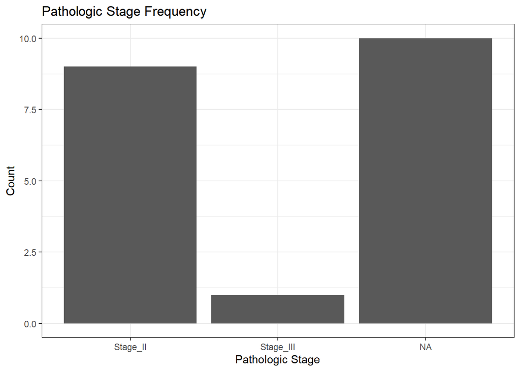

```r
ggplot(as.data.frame(sample_metadata),
       aes(x = paper_pathologic_stage)) +
  geom_bar() +
  theme_bw() +
  labs(
    title = "Pathologic Stage Frequency",
    x = "Pathologic Stage",
    y = "Count"
  )
```

To compare tumor and normal samples, we can color the bars by tissue_type. This allows us to quickly see which bars represent tumors and which represent normal tissue:

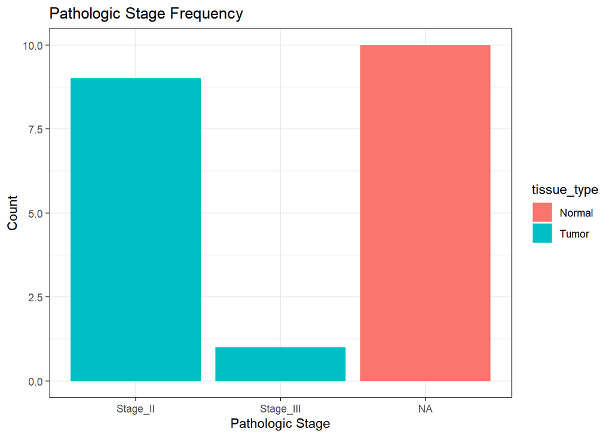

```r
ggplot(as.data.frame(sample_metadata),
       aes(x = paper_pathologic_stage, fill = tissue_type)) +
  geom_bar() +
  theme_bw() +
  labs(
    title = "Pathologic Stage Frequency",
    x = "Pathologic Stage",
    y = "Count"
  )
```

As expected, tumor samples have stage information, while normal tissue samples are assigned NA.

**Exercise**

What happens when you plot `ajcc_pathologic_stage` on the x-axis and color by `tissue_type`? Does the result make sense?

**Show Plot**

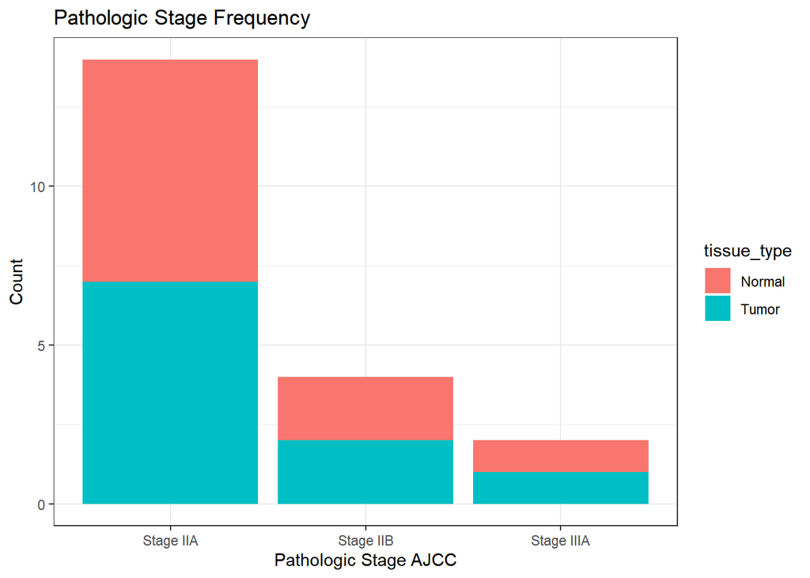

```r
ggplot(as.data.frame(sample_metadata),
       aes(x = ajcc_pathologic_stage, fill = tissue_type)) +
  geom_bar() +
  theme_bw() +
  labs(
    title = "Pathologic Stage Frequency",
    x = "Pathologic Stage AJCC",
    y = "Count"
  )
```

Notice that normal (healthy) tissue samples have a pathologic stage assigned. This likely reflects metadata inheritance from the donor rather than an actual tumor stage. Always carefully check metadata before using it for downstream analyses.

### Basic Expression Statistics

Before diving into sample-level explorations, we first log-transform the raw counts. This stabilizes variance and makes the data more suitable for visualization.

```r
logdata <- log2(expr_matrix + 1)

c_mean <- colMeans(logdata)
c_median <- apply(logdata, 2, median)
c_std <- apply(logdata, 2, sd)

rng <- 1:length(c_mean)

sumstats <- data.frame(
c_mean = c_mean,
c_median = c_median,
c_std = c_std,
rng = rng
)
```

**Exercise**

Why do we add 1 when performing the log-transformation?

**Show answer**

We add 1 to each value before taking the logarithm to handle zeros, because the logarithm of zero is undefined.

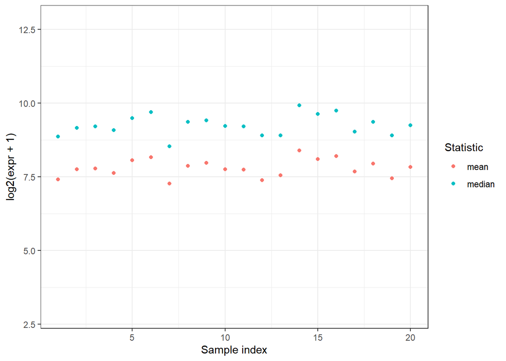

```r
ggplot(sumstats, aes(x = rng, y = c_median)) +
geom_point(aes(color = "median")) +
geom_point(aes(x = rng, y = c_mean, color = "mean")) +
ylim(range(c(c_mean - c_std, c_mean + c_std))) +
ylab("log2(expr + 1)") +
xlab("Sample index") +
theme_bw() +
labs(color = "Statistic")
```

This plot shows the mean and median expression for each sample. It provides a quick overview of the variation in expression across samples, helping us identify outliers or samples with unusual distributions.

### Expression Boxplots by Tissue Type

To visualize the distribution of gene expression values for each sample, separated by tissue type (tumor vs. normal)we first reshape the expression matrix into a long format suitable for `ggplot2`.

```r
long_logdata <- logdata %>%
  as.data.frame() %>%
  rownames_to_column(var = "gene") %>%
  pivot_longer(-gene, names_to = "barcode", values_to = "expr")

# Add tissue information from sample metadata
long_logdata <- long_logdata %>%
  left_join(as.data.frame(sample_metadata) %>%
              select(barcode, sample_type), by = "barcode") %>%
  arrange(sample_type, barcode) %>%  # order rows
  mutate(sample_ordered = factor(barcode, levels = unique(barcode)))  # factor for plotting
```

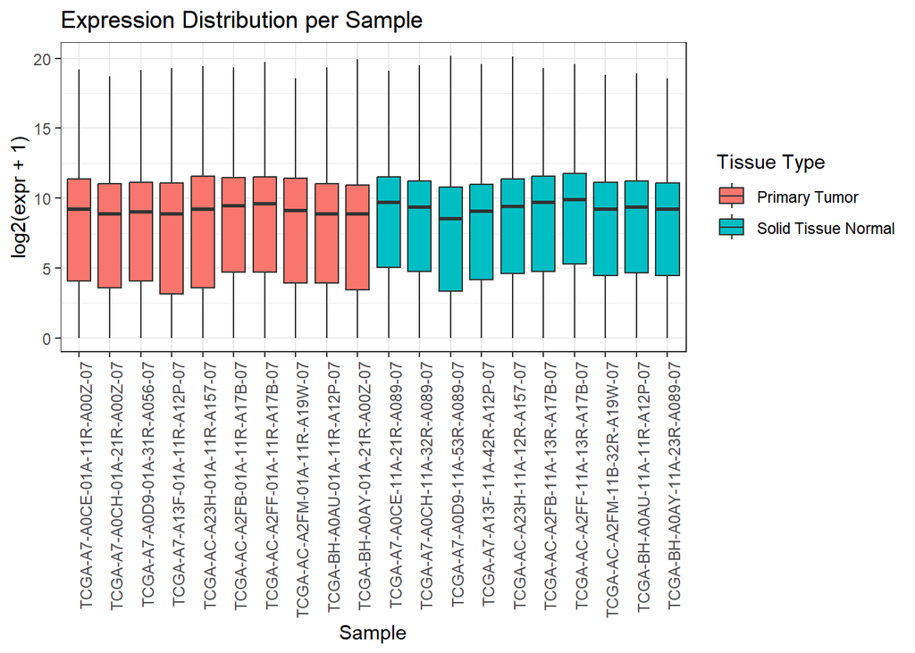

```r
ggplot(long_logdata, aes(x = sample_ordered, y = expr, fill = sample_type)) +
  geom_boxplot() +
  theme_bw() +
  labs(x = "Sample", y = "log2(expr + 1)", fill = "Tissue Type",
       title = "Expression Distribution per Sample") +
  theme(axis.text.x = element_text(angle = 90, hjust = 1))
```

Each boxplot shows the distribution of log<sub>2</sub>-transformed expression values for a single sample. Coloring by sample_type makes it easy to compare expression patterns between tumor and normal tissues at a glance.

**Exercise**

What information do the boxes represent?

**Show answer**

Each box represents the interquartile range (IQR), containing the middle 50% of expression values for that sample.

The line inside the box shows the median expression.

Whiskers extend to the most extreme points within 1.5× IQR, and points outside this range are considered outliers.

### Expression Distribution: Histograms and Density Plots

Histograms and density plots are useful for inspecting the distribution of expression values within individual samples. They allow us to see the overall shape of the data, including lowly expressed and highly expressed genes.

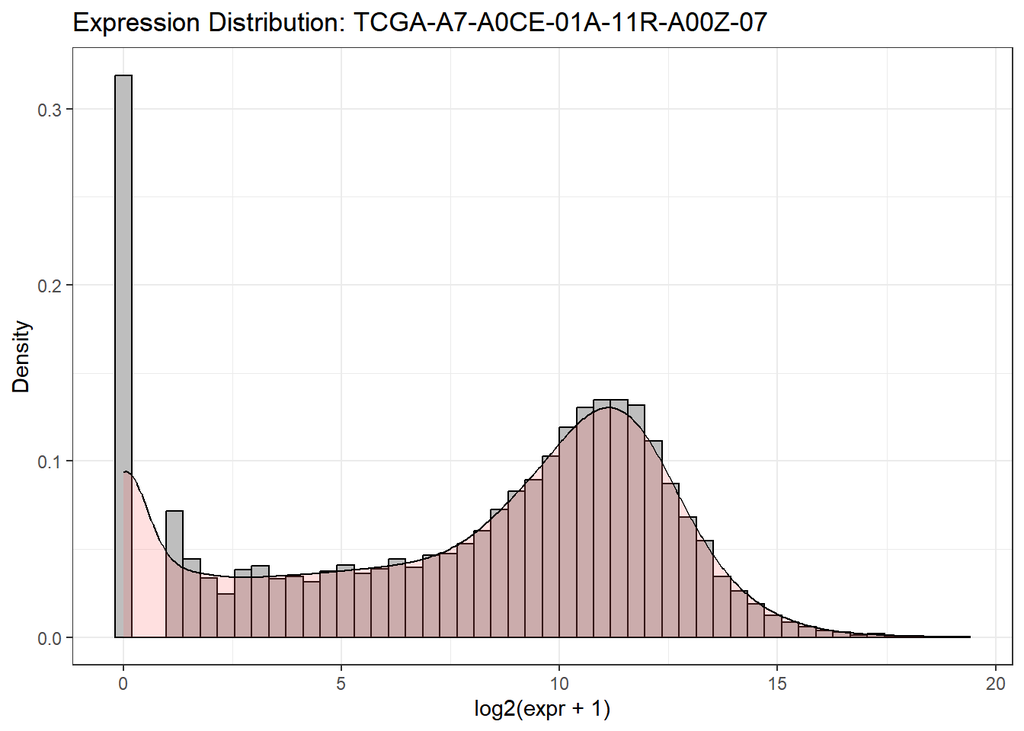

```r
# Select one sample to visualize
sample_name <- long_logdata$barcode[1]  # pick first sample, or specify your own
data_sample_name <- long_logdata %>% filter(barcode == sample_name)

# Histogram + density for a single sample
ggplot(data_sample_name, aes(x = expr)) +
  geom_histogram(aes(y = ..density..), color = "black", fill = "grey", bins = 50) +
  geom_density(alpha = 0.2, fill = "#FF6666") +
  theme_bw() +
  labs(title = paste("Expression Distribution:", sample_name),
       x = "log2(expr + 1)",
       y = "Density")
```

We can also compare multiple samples simultaneously using facet_wrap:

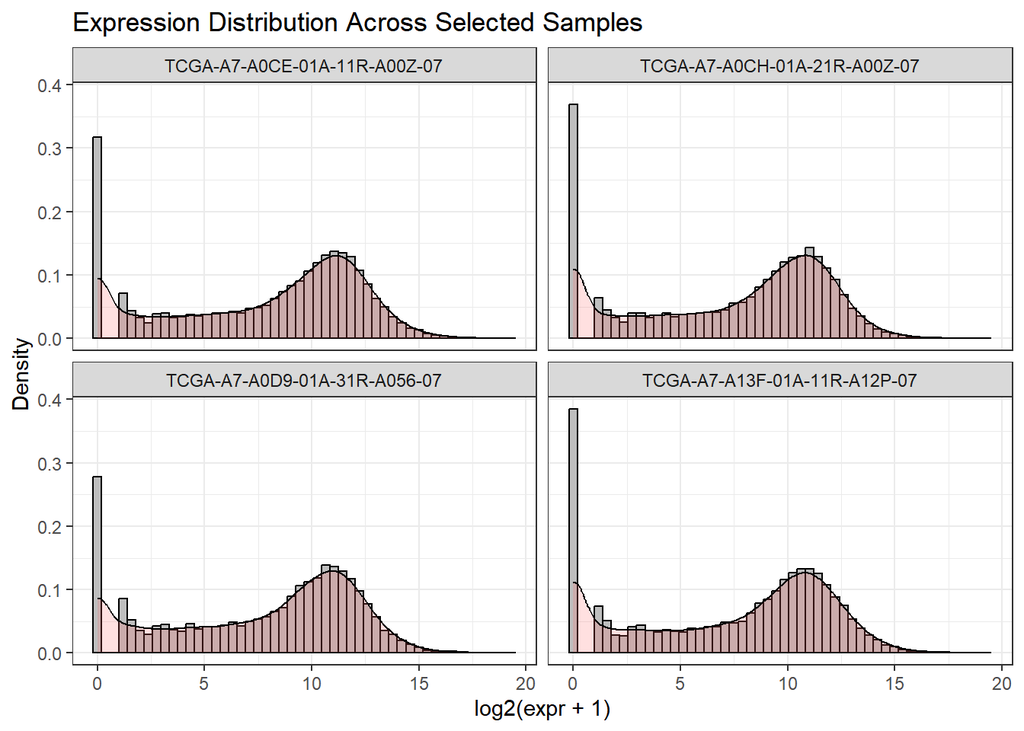

```r
# Now do the same for a small subset of samples (e.g., first 4 samples)
sample_name <- unique(long_logdata$barcode)[1:4]
data_sample_name <- long_logdata %>% filter(barcode %in% sample_name)

# Histogram + density faceted by sample
ggplot(data_sample_name, aes(x = expr)) +
  geom_histogram(aes(y = ..density..), color = "black", fill = "grey", bins = 50) +
  geom_density(alpha = 0.2, fill = "#FF6666") +
  facet_wrap(~barcode) +
  theme_bw() +
  labs(title = "Expression Distribution Across Selected Samples",
       x = "log2(expr + 1)",
       y = "Density")
```

A common pattern emerges: many genes have zero counts (a clear spike at 0), followed by a gap, and then a long tail of highly expressed genes.

**Exercise**

Why is it problematic to have many genes with zero counts, and what can we do about it?

**Show answer**

- Genes with zero counts across most samples provide little information and can introduce noise in downstream analyses like PCA or differential expression.
- One common solution is to filter out lowly expressed genes, e.g., keeping only genes with counts above a minimum threshold in a certain number of samples.

### Filtering Lowly Expressed Genes and Re-Plotting Expression Distributions

Many genes in RNA-seq data have zero or very low counts across samples. These genes contribute little biological insight and can introduce noise into downstream analyses such as PCA or differential expression testing. To mitigate this, we filter out lowly expressed genes before further analysis.

We use the `edgeR` package to calculate counts per million (CPM) and filter genes.The `filterByExpr` function provides a data-driven way to determine which genes have sufficient expression:

```r
keep <- filterByExpr(expr_matrix)
```

```
No group or design set. Assuming all samples belong to one group.
```

```r
summary(keep)
```

```
   Mode   FALSE    TRUE
logical    5454   14490
```

In theory, one could set a manual expression threshold, but this choice is often arbitrary. To better understand how `filterByExpr` makes its decision, consult the function’s documentation (place the cursor on the function and press F1).

**Exercise**

Why do we do CPM normalization?

**Show answer**

CPM normalization adjusts for differences in sequencing depth between samples. CPM rescales counts so that samples become comparable, ensuring that downstream analyses reflect biological differences rather than differences in library size.

Next, we log-transform the filtered CPM values for visualization:

```r
logcounts <- cpm(expr_matrix[keep,],log=TRUE,prior.count = 1)
```

We convert the log-transformed data to long format for plotting:

```r
long_logdata <- logcounts %>%
  as.data.frame() %>%
  rownames_to_column(var = "gene") %>%
  pivot_longer(-gene, names_to = "barcode", values_to = "expr")
```

Finally, we visualize the expression distributions for a subset of samples:

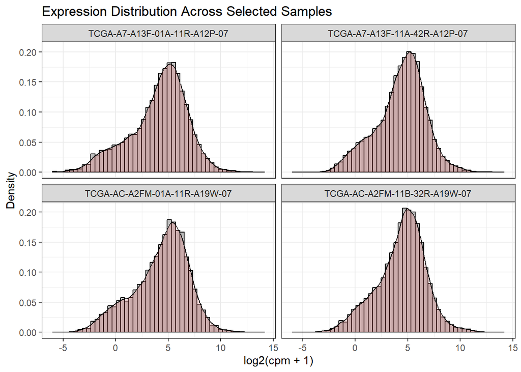

```r
# Select first 4 samples
sample_name <- unique(long_logdata$barcode)[1:4]
data_sample_name <- long_logdata %>% filter(barcode %in% sample_name)

# Histogram + density faceted by sample
ggplot(data_sample_name, aes(x = expr)) +
  geom_histogram(aes(y = ..density..), color = "black", fill = "grey", bins = 50) +
  geom_density(alpha = 0.2, fill = "#FF6666") +
  facet_wrap(~barcode) +
  theme_bw() +
  labs(title = "Expression Distribution Across Selected Samples",
       x = "log2(cpm + 1)",
       y = "Density")
```

**Exercise**

Why do we see negative values in the log2(CPM + 1) plots?

**Show answer**

Negative values occur because CPM values can be less than 1 for lowly expressed genes. When we compute log2(CPM + 1) on a value less than 1, the log₂ value becomes negative.

## Principal Component Analysis (PCA) of Filtered Expression Data

After filtering out lowly expressed genes, we can perform PCA to explore global patterns in gene expression. PCA reduces the dimensionality of the dataset by identifying combinations of genes (principal components) that explain the major sources of variation across samples.

Before applying PCA, we transpose the expression matrix so that samples are rows and genes are columns, as required for the PCA:

```r
pca <- prcomp(t(logcounts), center = TRUE, scale. = TRUE)
summary(pca)
```

```
Importance of components:
                           PC1    PC2     PC3      PC4      PC5      PC6
Standard deviation     59.2262 42.893 41.4477 35.41344 32.85968 29.93704
Proportion of Variance  0.2421  0.127  0.1186  0.08655  0.07452  0.06185
Cumulative Proportion   0.2421  0.369  0.4876  0.57416  0.64868  0.71053
                            PC7     PC8      PC9     PC10     PC11     PC12
Standard deviation     28.05168 26.6199 23.17244 22.51705 19.66069 17.49092
Proportion of Variance  0.05431  0.0489  0.03706  0.03499  0.02668  0.02111
Cumulative Proportion   0.76483  0.8137  0.85079  0.88579  0.91246  0.93358
                           PC13     PC14     PC15     PC16     PC17    PC18
Standard deviation     15.59945 13.75054 11.78043 11.13522 10.13908 9.73233
Proportion of Variance  0.01679  0.01305  0.00958  0.00856  0.00709 0.00654
Cumulative Proportion   0.95037  0.96342  0.97300  0.98155  0.98865 0.99518
                          PC19      PC20
Standard deviation     8.35344 9.009e-14
Proportion of Variance 0.00482 0.000e+00
Cumulative Proportion  1.00000 1.000e+00
```

Convert PCA results to a data frame for plotting:

```r
pca_df <- as.data.frame(pca$x)
```

Add sample metadata for plotting:

```r
pca_df <- pca_df %>%
  rownames_to_column("barcode") %>%
  left_join(
    as.data.frame(sample_metadata) %>% select(barcode, tissue_type, paper_BRCA_Subtype_PAM50),
    by = "barcode"
  )
```

Plot the first two principal components:

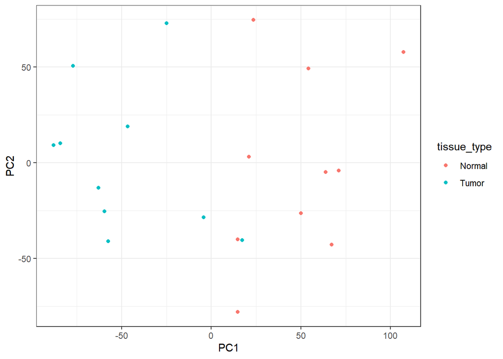

```r
ggplot(pca_df, aes(PC1, PC2, color = tissue_type)) +
  geom_point() +
  theme_bw()
```

We can see that the first principal component (PC1) separates the samples clearly into healthy tissue versus tumor samples. This indicates that the largest source of variation in the dataset corresponds to tissue type, reflecting the fundamental biological differences between normal and cancerous breast tissue.

We can also examine how known molecular breast cancer subtypes behave in PCA space by coloring samples according to their PAM50 subtype:

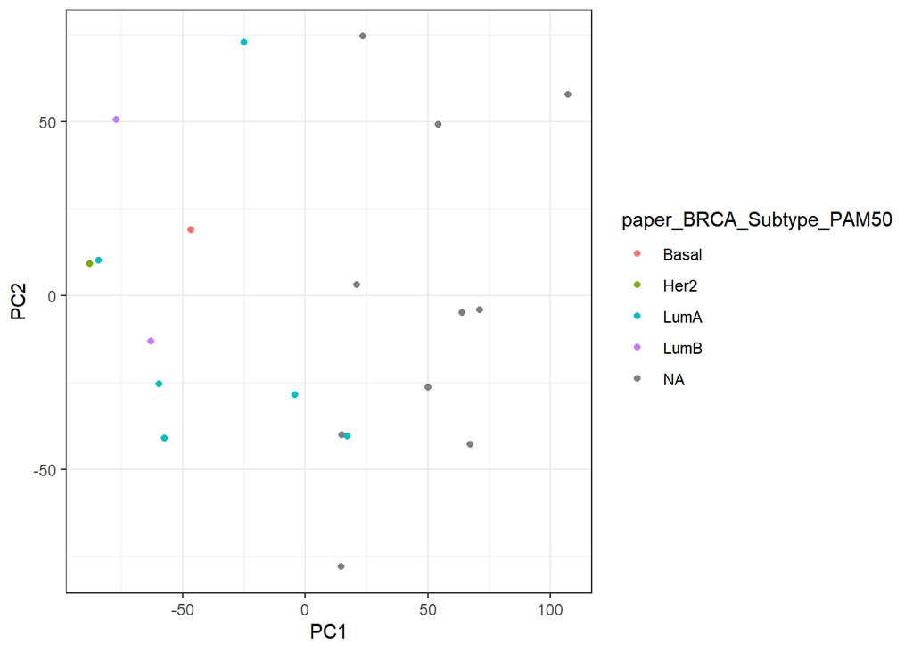

```r
ggplot(pca_df, aes(PC1, PC2, color = paper_BRCA_Subtype_PAM50)) +
  geom_point() +
  theme_bw()
```

## Differential Gene Expression (DGE) Analysis

To identify genes that are differentially expressed between tumor and normal tissue, we use the `DESeq2` package, a widely adopted tool for RNA-seq analysis. `DESeq2` models raw count data using negative binomial statistics, accounting for differences in sequencing depth and biological variability. It provides methods for:

- Normalization of counts across samples
- Estimation of gene-wise dispersion
- Hypothesis testing for differential expression
- Log2 fold change shrinkage for more stable estimates

This workflow allows us to identify genes that are significantly upregulated or downregulated in tumors relative to normal tissue, which can highlight potential biomarkers or therapeutic targets.

```r
# Create DESeqDataSet with tissue type as the variable of interest
brca_DEseq <- DESeqDataSet(brca_data[keep,], design = ~ tissue_type)
brca_DEseq
```

```
class: DESeqDataSet
dim: 14490 20
metadata(2): data_release version
assays(6): counts stranded_first ... fpkm_unstrand fpkm_uq_unstrand
rownames(14490): TSPAN6 DPM1 ... DUS4L-BCAP29 AP006621.6
rowData names(10): source type ... hgnc_id havana_gene
colnames(20): TCGA-A7-A13F-01A-11R-A12P-07 TCGA-AC-A2FM-01A-11R-A19W-07
  ... TCGA-A7-A0CH-01A-21R-A00Z-07 TCGA-A7-A0CE-01A-11R-A00Z-07
colData names(84): barcode patient ... paper_PARADIGM Clusters
  paper_Pan-Gyn Clusters
```

Next, we set Normal as the reference level so that the fold changes are interpreted as Tumor vs Normal.

```r
brca_DEseq$tissue_type <- relevel(brca_DEseq$tissue_type, ref = "Normal")
```

DESeq2 then performs a multi-step procedure:

- Normalization of sample sequencing depth
- Estimation of gene-wise dispersion
- Fitting generalized linear models
- Computing log2 fold changes (LFC) and adjusted p-values

```r
brca_DEseq <- DESeq(brca_DEseq, useT = TRUE)
```

```
-- replacing outliers and refitting for 393 genes
-- DESeq argument 'minReplicatesForReplace' = 7
-- original counts are preserved in counts(dds)
```

```r
DGE_res <- results(brca_DEseq, contrast=c("tissue_type","Tumor","Normal"))
```

```r
summary(DGE_res)
```

```
out of 14490 with nonzero total read count
adjusted p-value < 0.1
LFC > 0 (up)       : 3221, 22%
LFC < 0 (down)     : 2434, 17%
outliers [1]       : 0, 0%
low counts [2]     : 0, 0%
(mean count < 16)
[1] see 'cooksCutoff' argument of ?results
[2] see 'independentFiltering' argument of ?results
```

Raw log2 fold changes can be unstable for genes with low counts. `DESeq2` provides shrinkage methods, such as “apeglm”, to stabilize these estimates:

```r
DGE_res_shrink <- lfcShrink(brca_DEseq, coef = "tissue_type_Tumor_vs_Normal", type = "apeglm")
```

```
using 'apeglm' for LFC shrinkage. If used in published research, please cite:
    Zhu, A., Ibrahim, J.G., Love, M.I. (2018) Heavy-tailed prior distributions for
    sequence count data: removing the noise and preserving large differences.
    Bioinformatics. https://doi.org/10.1093/bioinformatics/bty895
```

MA plots visualize the relationship between mean expression and log2 fold change. They help identify genes with strong changes relative to their expression level.

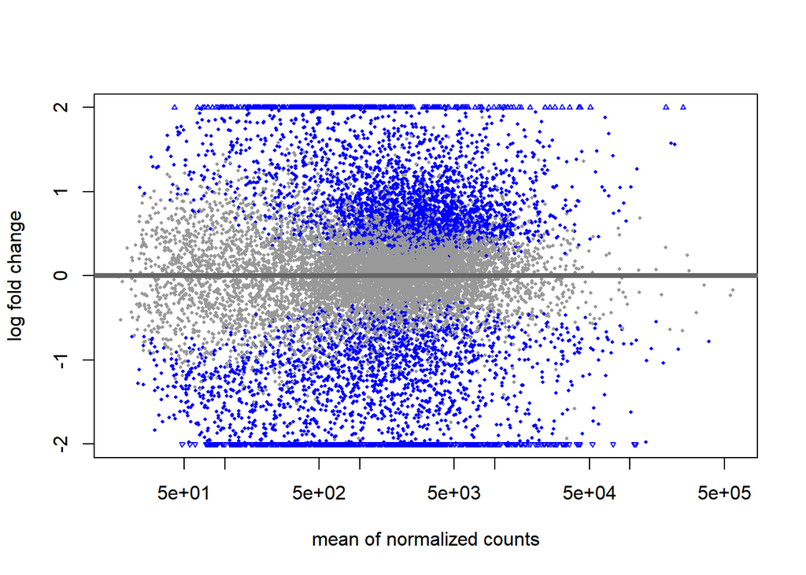

```r
BiocGenerics::plotMA(DGE_res, ylim=c(-2,2))
```

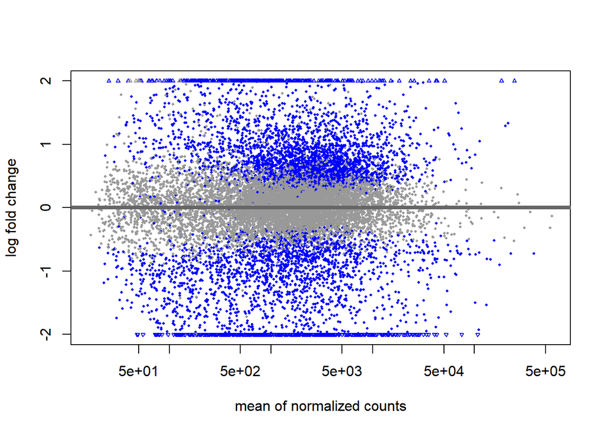

```r
BiocGenerics::plotMA(DGE_res_shrink, ylim=c(-2,2))
```

**Exercise**

Can you spot the difference the shrinkage of the LFC? Why is this performed?

**Show answer**

For genes with low counts, the raw log2 fold changes can be very noisy and exaggerated. Shrinkage pulls these genes LFC values closer to zero (visible in the plots), reducing noise and providing more reliable, interpretable estimates of differential expression.

The volcano plot provides a combined view of fold change and significance, allowing rapid identification of biologically relevant genes.

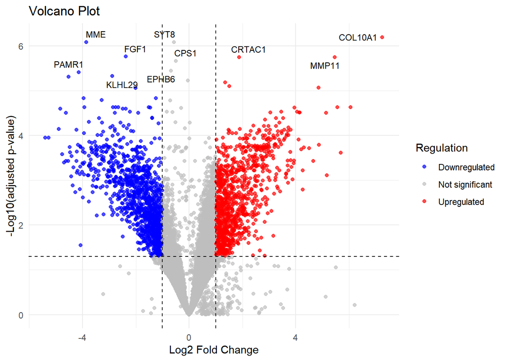

```r
# Prepare results table
volcano_df <- as.data.frame(DGE_res_shrink) %>%
  rownames_to_column("gene") %>%
  mutate(
    neg_log10_p = -log10(padj),
    regulation = case_when(
      padj < 0.05 & log2FoldChange > 1  ~ "Upregulated",
      padj < 0.05 & log2FoldChange < -1 ~ "Downregulated",
      TRUE ~ "Not significant"
    )
  )

# Select top genes to label (top 10 smallest adjusted p-values)
top_genes <- volcano_df %>%
  arrange(padj) %>%
  slice_head(n = 10)

ggplot(volcano_df, aes(x = log2FoldChange, y = neg_log10_p)) +
  geom_point(aes(color = regulation), alpha = 0.7, size = 1.5) +
  scale_color_manual(values = c(
    "Upregulated" = "red",
    "Downregulated" = "blue",
    "Not significant" = "grey"
  )) +
  geom_vline(xintercept = c(-1, 1), linetype = "dashed") +
  geom_hline(yintercept = -log10(0.05), linetype = "dashed") +
  geom_text_repel(
    data = top_genes,
    aes(label = gene),
    size = 3,
    max.overlaps = 20
  ) +
  labs(
    title = "Volcano Plot",
    x = "Log2 Fold Change",
    y = "-Log10(adjusted p-value)",
    color = "Regulation"
  ) +
  theme_minimal()
```

**Exercise**

How is the volcano plot interpreted?

**Show answer**

- X-axis: magnitude of change (log2 fold change)
- Y-axis: statistical significance (-log10 adjusted p-value)
- Top right points: significantly upregulated in tumors
- Top left points: significantly downregulated in tumors
- Grey points: not statistically significant
- Dashed lines: thresholds for fold change (|LFC| ≥ 1) and significance (padj < 0.05)
- The labeled points highlight the most significant genes based on adjusted p-values.

If you want, you can look up these genes later and see if there are any papers mentioning a connection with BRCA.

## Foot Print Analysis

### Pathway signaling activities with PROGENy

In this section we estimate pathway activities using PROGENy, a comprehensive resource containing a curated collection of pathways and their target genes, with weights for each interaction. You can find a vignette for its usage with decoupleR and a description of each pathway [here](https://saezlab.github.io/decoupleR/articles/pw_bk.html#progeny-model).

From the DESeq2 results we extract the gene-level statistics needed for footprint-based inference:

```r
deg <- as.matrix(setNames(DGE_res$stat, rownames(DGE_res))[
    !is.na(DGE_res$stat)
])
```

Next, we obtain the PROGENy model. The network encodes weighted relationships between pathways (sources) and their responsive genes (targets):

```r
# net_progeny <- get_progeny(organism = 'human', top = 500)
# saveRDS(net_progeny, file = "net_progeny.rds")

net_progeny <- readRDS("net_progeny.rds")
kable(head(net_progeny))
```

| source | target | weight | p_value |
| --- | --- | --- | --- |
| Androgen | TMPRSS2 | 11.490631 | 0 |
| Androgen | NKX3-1 | 10.622551 | 0 |
| Androgen | MBOAT2 | 10.472733 | 0 |
| Androgen | KLK2 | 10.176186 | 0 |
| Androgen | SARG | 11.386852 | 0 |
| Androgen | SLC38A4 | 7.363805 | 0 |

#### Pathway Activities per Sample

We can estimate pathway activities at the sample level using multivariate linear modeling (MLM) implemented in decoupleR. Here, the filtered logcounts are used as input:

```r
sample_acts <- run_mlm(mat = logcounts,
                              net = net_progeny,
                              .source = 'source',
                              .target = 'target',
                              .mor = 'weight',
                              minsize = 5)
```

```r
kable(head(sample_acts))
```

| statistic | source | condition | score | p_value |
| --- | --- | --- | --- | --- |
| mlm | Androgen | TCGA-A7-A13F-01A-11R-A12P-07 | 2.4028879 | 0.0162787 |
| mlm | EGFR | TCGA-A7-A13F-01A-11R-A12P-07 | -1.5772743 | 0.1147543 |
| mlm | Estrogen | TCGA-A7-A13F-01A-11R-A12P-07 | 2.0686445 | 0.0385972 |
| mlm | Hypoxia | TCGA-A7-A13F-01A-11R-A12P-07 | 0.6000234 | 0.5485000 |
| mlm | JAK-STAT | TCGA-A7-A13F-01A-11R-A12P-07 | -0.3130355 | 0.7542582 |
| mlm | MAPK | TCGA-A7-A13F-01A-11R-A12P-07 | -0.3170795 | 0.7511878 |

The output contains a score for each PROGENy pathway in every sample. To visualize the patterns, we transform the data into a matrix, scale each pathway for better visualization, and generate a heatmap:

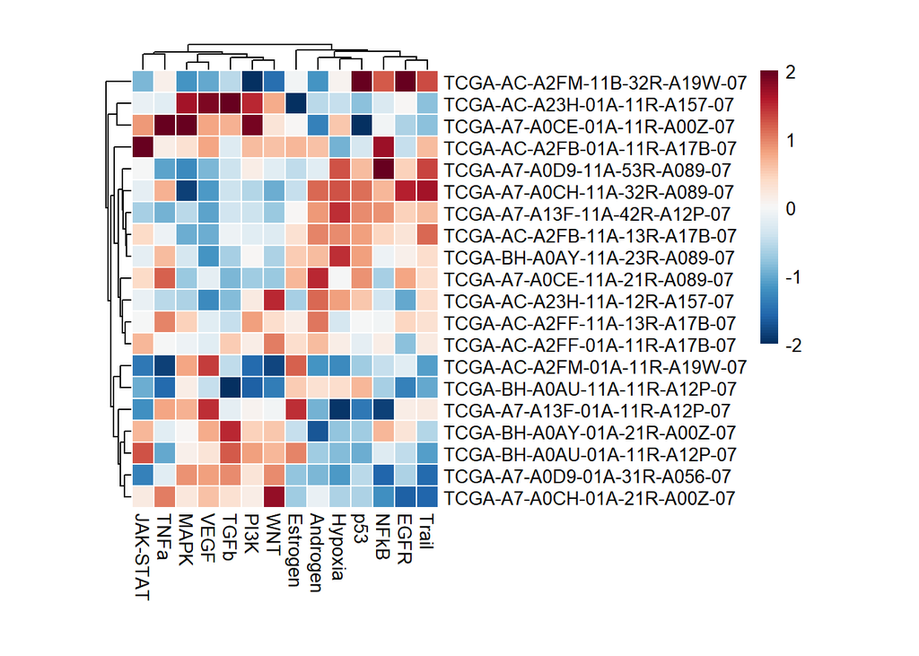

```r
# Transform to wide matrix
sample_acts_mat <- sample_acts %>%
                   pivot_wider(id_cols = 'condition',
                                      names_from = 'source',
                                      values_from = 'score') %>%
                   column_to_rownames('condition') %>%
                   as.matrix()

# Scale per feature
sample_acts_mat <- scale(sample_acts_mat)

# Color scale
colors <- rev(RColorBrewer::brewer.pal(n = 11, name = "RdBu"))
colors.use <- colorRampPalette(colors = colors)(100)

my_breaks <- c(seq(-2, 0, length.out = ceiling(100 / 2) + 1),
              seq(0.05,2, length.out = floor(100 / 2)))

# Plot
pheatmap::pheatmap(mat = sample_acts_mat,
                   color = colors.use,
                   border_color = "white",
                   breaks = my_breaks,
                   cellwidth = 12,
                   cellheight = 12,
                   treeheight_row = 10,
                   treeheight_col = 10)
```

#### Pathway Activities from Differential Statistics

We can also estimate contrast-level pathway activities directly from the differential expression statistics. This provides a summary of which pathways are up- or down-regulated between conditions:

```r
# Run mlm
contrast_acts <- run_mlm(mat  =deg,
                                net = net_progeny,
                                .source = 'source',
                                .target = 'target',
                                .mor = 'weight',
                                minsize = 5)

kable(head(contrast_acts))
```

| statistic | source | condition | score | p_value |
| --- | --- | --- | --- | --- |
| mlm | Androgen | 1 | -1.5367472 | 0.1243771 |
| mlm | EGFR | 1 | -2.5178270 | 0.0118188 |
| mlm | Estrogen | 1 | -0.2296766 | 0.8183463 |
| mlm | Hypoxia | 1 | -4.7075542 | 0.0000025 |
| mlm | JAK-STAT | 1 | 3.8346660 | 0.0001263 |
| mlm | MAPK | 1 | 4.4998037 | 0.0000069 |

Finally, we plot the pathway scores as a bar chart to highlight pathways with the strongest inferred changes:

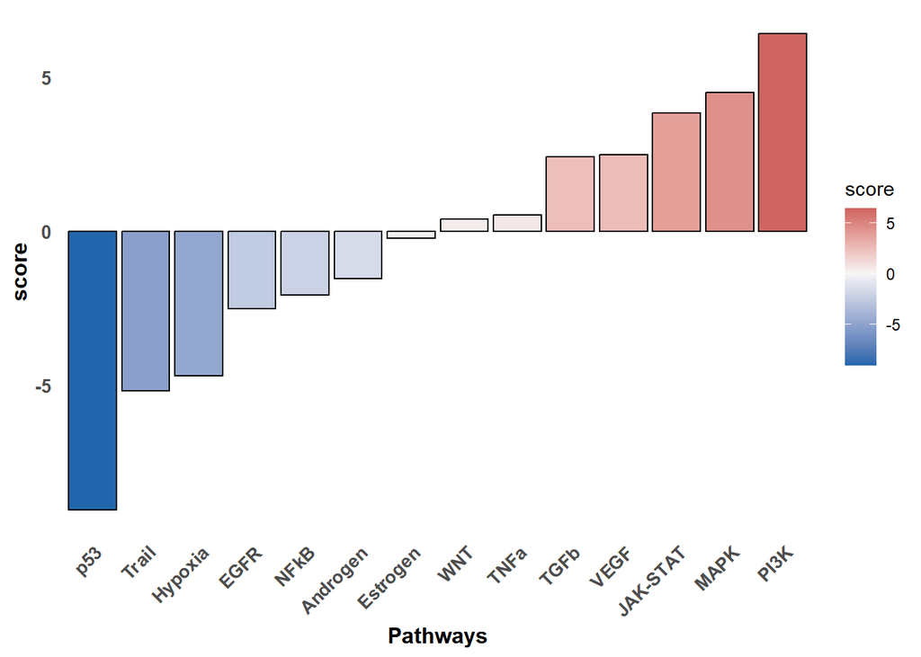

```r
# Plot
colors <- rev(RColorBrewer::brewer.pal(n = 11, name = "RdBu")[c(2, 10)])

p <- ggplot(data = contrast_acts,
                     mapping = aes(x = stats::reorder(source, score),
                                            y = score)) +
     geom_bar(mapping = aes(fill = score),
                       color = "black",
                       stat = "identity") +
     scale_fill_gradient2(low = colors[1],
                                   mid = "whitesmoke",
                                   high = colors[2],
                                   midpoint = 0) +
     theme_minimal() +
     theme(axis.title = element_text(face = "bold", size = 12),
              axis.text.x = element_text(angle = 45,
                                                  hjust = 1,
                                                  size = 10,
                                                  face = "bold"),
              axis.text.y = element_text(size = 10,
                                                  face = "bold"),
              panel.grid.major = element_blank(),
              panel.grid.minor = element_blank()) +
     xlab("Pathways")

p
```

**Exercise**

Which pathways are most strongly up- or down-regulated? Does this pattern match what you would expect based on the biology of your samples?

**Show answer**

Downregulated in tumor samples:

- p53: regulates cell cycle, apoptosis, DNA repair and tumor suppression.
- Trail: induces apoptosis.

Upregulated in the tumor samples:

- PI3K: promotes growth and proliferation
- MAPK: integrates external signals and promotes cell growth and proliferation.
- JAK-STAT: involved in immunity, cell division, cell death, and tumor formation.

These trends are consistent with the known behavior of tumor cells.

### Transcription factor acitivities with CollecTRI

In addition to pathway analysis, we can infer transcription factor (TF) activities using CollecTRI, a curated database of TF-target interactions. CollecTRI includes experimentally validated regulatory relationships between TFs (sources) and their target genes (targets), along with mode-of-regulation information (mor), indicating activation or repression.

We first load the CollecTRI network for human:

```r
# net_collectri <- get_collectri(organism = 'human',
#                                 split_complexes = FALSE)
#
# saveRDS(net_collectri, file = "net_collectri.rds")
net_collectri <- readRDS("net_collectri.rds")
```

#### Transcription factor Activities per Sample

Similar to the pathway analysis, we can estimate TF activity at the sample level using multivariate linear modeling (MLM). Here, the input is the filtered logcounts expression matrix:

```r
sample_acts <- run_mlm(mat = logcounts,
                              net = net_collectri,
                                  .source = 'source',
                                  .target = 'target',
                                  .mor = 'mor',
                                  minsize = 5)
```

The output contains a TF activity score for each TF in every sample. To visualize the most informative TFs, we select those with the largest variability across samples:

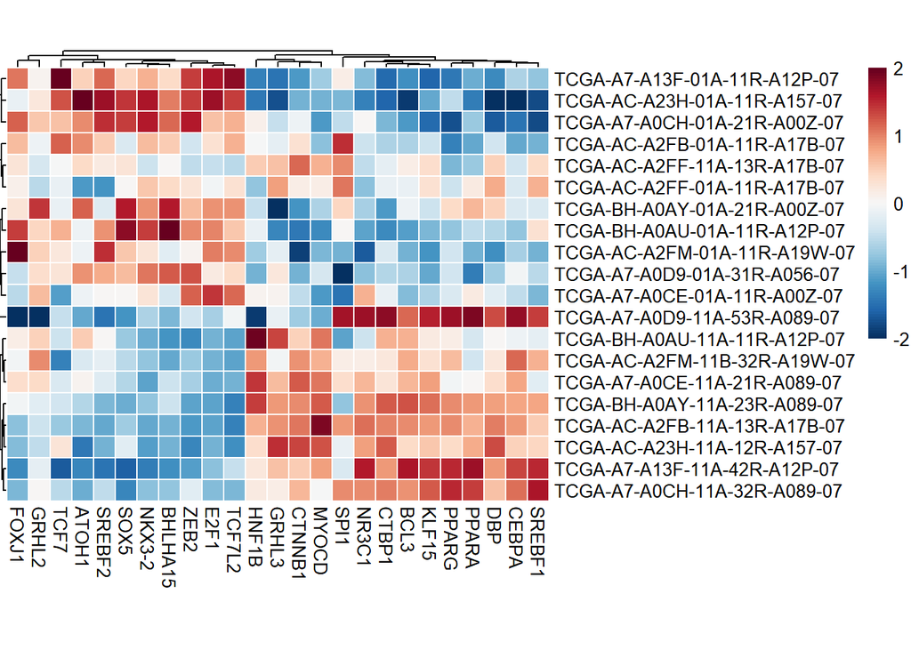

```r
n_tfs <- 25

# Transform to wide matrix
sample_acts_mat <- sample_acts %>%
                   pivot_wider(id_cols = 'condition',
                                      names_from = 'source',
                                      values_from = 'score') %>%
                   column_to_rownames('condition') %>%
                   as.matrix()

# Get top tfs with more variable means across clusters
tfs <- sample_acts %>%
       group_by(source) %>%
       summarise(std = sd(score)) %>%
       arrange(-abs(std)) %>%
       head(n_tfs) %>%
       pull(source)

sample_acts_mat <- sample_acts_mat[,tfs]

# Scale per sample
sample_acts_mat <- scale(sample_acts_mat)

# Choose color palette
colors <- rev(RColorBrewer::brewer.pal(n = 11, name = "RdBu"))
colors.use <- grDevices::colorRampPalette(colors = colors)(100)

my_breaks <- c(seq(-2, 0, length.out = ceiling(100 / 2) + 1),
               seq(0.05, 2, length.out = floor(100 / 2)))

# Plot
pheatmap::pheatmap(mat = sample_acts_mat,
                   color = colors.use,
                   border_color = "white",
                   breaks = my_breaks,
                   cellwidth = 12,
                   cellheight = 12,
                   treeheight_row = 5,
                   treeheight_col = 5)
```

#### Transcription factor Activities from Differential Statistics

We can also infer TF activities from differential expression statistics (contrast-level), which summarizes how each TF is activated or repressed between conditions. Here, we use the univariate linear model (ULM) approach:

```r
contrast_acts <- run_ulm(mat = deg,
                                    net = net_collectri,
                                    .source = 'source',
                                    .target = 'target',
                                    .mor='mor',
                                    minsize = 5)
```

To focus on the most strongly altered TFs, we rank TFs based on absolute score and filter for the top 25:

```r
# Filter top TFs in both signs
f_contrast_acts <- contrast_acts %>%
                   mutate(rnk = NA)

msk <- f_contrast_acts$score > 0

f_contrast_acts[msk, 'rnk'] <- rank(-f_contrast_acts[msk, 'score'])
f_contrast_acts[!msk, 'rnk'] <- rank(-abs(f_contrast_acts[!msk, 'score']))

tfs <- f_contrast_acts %>%
       arrange(rnk) %>%
       head(n_tfs) %>%
       pull(source)

f_contrast_acts <- f_contrast_acts %>%
                   filter(source %in% tfs)
```

Finally, we plot the contrast-level TF activities as a bar chart:

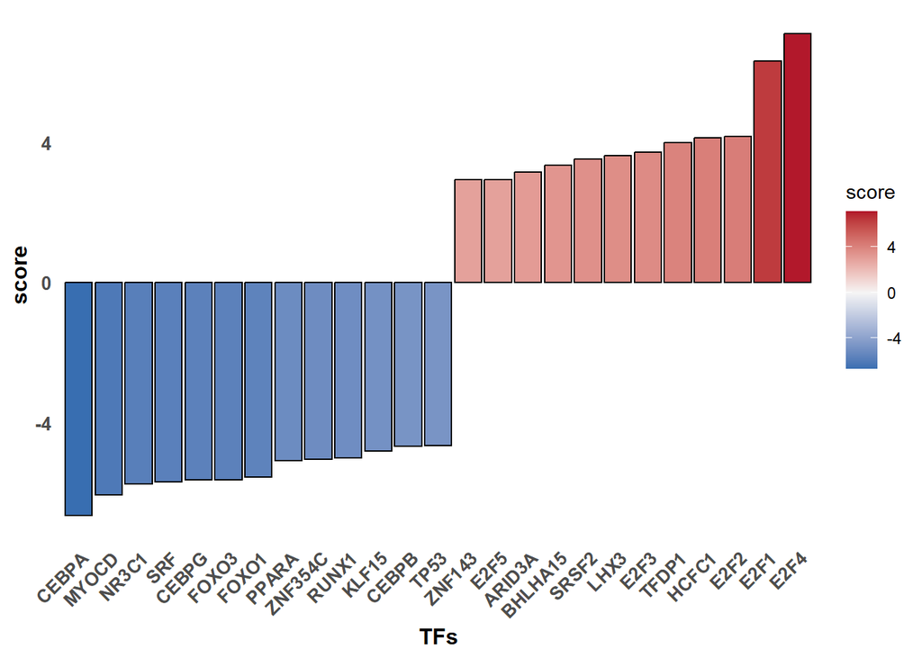

```r
colors <- rev(RColorBrewer::brewer.pal(n = 11, name = "RdBu")[c(2, 10)])

p <- ggplot(data = f_contrast_acts,
                     mapping = aes(x = stats::reorder(source, score),
                                            y = score)) +
     geom_bar(mapping = aes(fill = score),
                       color = "black",
                       stat = "identity") +
     scale_fill_gradient2(low = colors[1],
                                   mid = "whitesmoke",
                                   high = colors[2],
                                   midpoint = 0) +
     theme_minimal() +
     theme(axis.title = element_text(face = "bold", size = 12),
              axis.text.x = element_text(angle = 45,
                                                  hjust = 1,
                                                  size = 10,
                                                  face = "bold"),
              axis.text.y = element_text(size = 10,
                                                  face = "bold"),
              panel.grid.major = element_blank(),
              panel.grid.minor = element_blank()) +
     xlab("TFs")

p
```

**Exercise**

What is the difference between ULM and MLM methods ?

**Show answer**

ULM (Univariate Linear Model):

- Tests each TF independently, so you don’t have to worry about highly correlated TFs in the network.
- However, it can produce false positives and does not account for interactions between TFs.

MLM (Multivariate Linear Model):

- Models all TFs jointly, accounting for overlapping targets and interaction effects.
- If your network is highly co-linear (some TF pairs have correlation > 0.9, you can check with check_corr(net)), MLM can give unstable results.